# Exercise1

Jayme de Queiroz

#### 1- A Dream Airlines tem o seguinte mapa de rotas para as cidades que atende, onde cada par de cidades tem serviço em ambas as direções entre as cidades:

Albuquerque - Atlanta  
Chicago - New York  
Chicago - Pinhais  
Curitiba - Atlanta  
Curitiba - Chicago  
Curitiba - Miami  
Curitiba - New York  
Curitiba - Sao Paulo  
Londrina - Foz  
Maringa - Albuquerque  
Maringa - Cleveland  
Miami - Denver  
Miami - New York  
Miami - Philadelphia  
Minneapolis - Foz  
New York - Cleveland  
New York - Minneapolis  
Philadelphia - Atlanta  
Phoenix - Cleveland  
Phoenix - Maringa  
Pinhais - Londrina  
Ponta Grossa - Cleveland  
Ponta Grossa - Foz  
Ponta Grossa - Londrina  
Sao Paulo - Boston  
Sao Paulo - Chicago  
Sao Paulo - Foz  
Sao Paulo - Londrina  
Sao Paulo - Minneapolis  
Sao Paulo - Ponta Grossa  
Tulsa - Maringa  
Tulsa - New York

Construa um grafo apropriado que represente esses relacionamentos utilizando o Networkx. A rede produzida deve ficar mais ou menos assim:

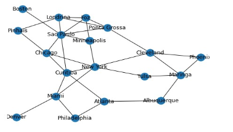

```python
import networkx as nx
import matplotlib.pyplot as plt
```

```python
# Criando um grafo direcionado
G = nx.Graph()

# Adicionando arestas com os pares de cidades
routes = [
    ("Albuquerque", "Atlanta"),
    ("Chicago", "New York"),
    ("Chicago", "Pinhais"),
    ("Curitiba", "Atlanta"),
    ("Curitiba", "Chicago"),
    ("Curitiba", "Miami"),
    ("Curitiba", "New York"),
    ("Curitiba", "Sao Paulo"),
    ("Londrina", "Foz"),
    ("Maringa", "Albuquerque"),
    ("Maringa", "Cleveland"),
    ("Miami", "Denver"),
    ("Miami", "New York"),
    ("Miami", "Philadelphia"),
    ("Minneapolis", "Foz"),
    ("New York", "Cleveland"),
    ("New York", "Minneapolis"),
    ("Philadelphia", "Atlanta"),
    ("Phoenix", "Cleveland"),
    ("Phoenix", "Maringa"),
    ("Pinhais", "Londrina"),
    ("Ponta Grossa", "Cleveland"),
    ("Ponta Grossa", "Foz"),
    ("Ponta Grossa", "Londrina"),
    ("Sao Paulo", "Boston"),
    ("Sao Paulo", "Chicago"),
    ("Sao Paulo", "Foz"),
    ("Sao Paulo", "Londrina"),
    ("Sao Paulo", "Minneapolis"),
    ("Sao Paulo", "Ponta Grossa"),
    ("Tulsa", "Maringa"),
    ("Tulsa", "New York")
]

# Adicionando arestas ao grafo
G.add_edges_from(routes)
```

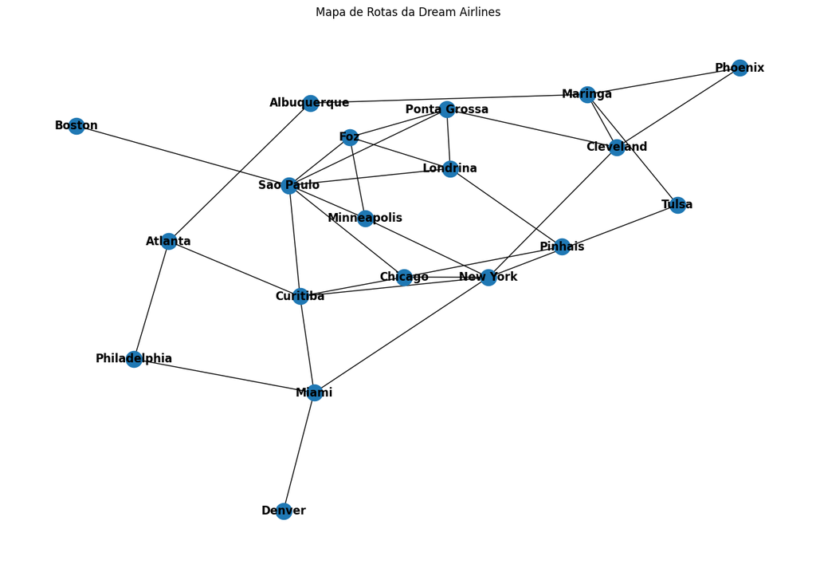

```python
# Plotando o grafo
plt.figure(figsize=(12, 8))
nx.draw(G, with_labels=True, font_weight='bold', node_size=300)
plt.title("Mapa de Rotas da Dream Airlines")
plt.show()
```

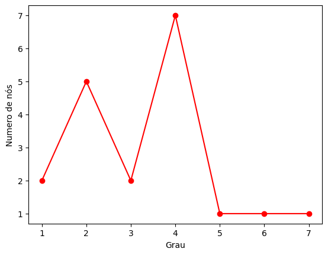

```python
dicDegree = dict(G.degree() )
valores = sorted(set(dicDegree.values()))
valores

hist = [list(dicDegree.values()).count(x) for x in valores]


plt.plot(valores, hist, 'ro-')

plt.xlabel('Grau')
plt.ylabel('Numero de nós')
```

#### 2- Com base na rede construída no exercício 1, faça o que é proposto abaixo.\

a- Qual é o número máximo de saltos que um passageiro pode fazer em uma única viagem entre duas cidades atendidas?  
b- Qual é o coeficiente de clusterização de Curitiba? E da rede geral?

```python
# a) Número máximo de saltos
max_hops = nx.diameter(G)
print("a) O número máximo de saltos em uma única viagem entre duas cidades atendidas é:", max_hops)

# b) Coeficiente de clusterização de Curitiba
#    Coeficiente de clusterização médio da rede geral
average_clustering = nx.average_clustering(G)
curitiba_clustering = nx.clustering(G, "Curitiba")
print(f"b) O coeficiente de clusterização de Curitiba é:{curitiba_clustering:.4f}, e o da rede geral é {average_clustering:.4f}")
```

```
a) O número máximo de saltos em uma única viagem entre duas cidades atendidas é: 4
b) O coeficiente de clusterização de Curitiba é:0.3000, e o da rede geral é 0.2371
```

#### 3- Estenda a rede criada na questão 1

a- Adicione o atributo nos nós chamado Country, onde o valor se refere ao país onde cada cidade está localizada.

```python
# Adicionando atributo "Country" aos nós
country_mapping = {
    "Albuquerque": "USA",
    "Atlanta": "USA",
    "Chicago": "USA",
    "Pinhais": "BR",
    "Curitiba": "BR",
    "Miami": "USA",
    "New York": "USA",
    "Sao Paulo": "BR",
    "Londrina": "BR",
    "Foz": "BR",
    "Maringa": "BR",
    "Cleveland": "USA",
    "Denver": "USA",
    "Minneapolis": "USA",
    "Philadelphia": "USA",
    "Boston": "USA",
    "Phoenix": "USA",
    "Ponta Grossa": "BR",
    "Tulsa": "USA"
}

nx.set_node_attributes(G, country_mapping, "Country")
```

b- Adicione o atributo nas arestas chamado Cost. Se uma arestas representa um voo internacional esse valor deve ser 5, se ela representa um voo nacional o valor deve ser 1.

```python
# Adicionando atributo "Cost" às arestas
for edge in G.edges():
    source = edge[0]
    target = edge[1]
    if G.nodes[source]["Country"] == G.nodes[target]["Country"]:
        G.edges[source, target]["Cost"] = 1  # Voo nacional
    else:
        G.edges[source, target]["Cost"] = 5  # Voo internacional
```

#### 4 – Exporte a rede final criada na questão 3 no formato .GML. Confira se todas as informações pedidas anteriormente estão disponíveis nesse arquivo.

[figure not shown]

```python
# Exportar a rede final para o formato .GML
nx.write_gml(G, "rede_final.gml")

# Ler o arquivo .GML para verificar se as informações foram corretamente exportadas
G_from_file = nx.read_gml("rede_final.gml")

# Verificar se as informações dos nós e arestas estão corretas
print("Atributos dos nós:")
print(f"G_from_file{G_from_file.nodes(data=True)}")
print(f"G          {G.nodes(data=True)}")
print("\nAtributos das arestas:")
print(f"G_from_file{G_from_file.edges(data=True)}")
print(f"           {G.edges(data=True)}")
```

```
Atributos dos nós:
G_from_file[('Albuquerque', {'Country': 'USA'}), ('Atlanta', {'Country': 'USA'}), ('Chicago', {'Country': 'USA'}), ('New York', {'Country': 'USA'}), ('Pinhais', {'Country': 'BR'}), ('Curitiba', {'Country': 'BR'}), ('Miami', {'Country': 'USA'}), ('Sao Paulo', {'Country': 'BR'}), ('Londrina', {'Countr…
G          [('Albuquerque', {'Country': 'USA'}), ('Atlanta', {'Country': 'USA'}), ('Chicago', {'Country': 'USA'}), ('New York', {'Country': 'USA'}), ('Pinhais', {'Country': 'BR'}), ('Curitiba', {'Country': 'BR'}), ('Miami', {'Country': 'USA'}), ('Sao Paulo', {'Country': 'BR'}), ('Londrina', {'Countr…

Atributos das arestas:
G_from_file[('Albuquerque', 'Atlanta', {'Cost': 1}), ('Albuquerque', 'Maringa', {'Cost': 5}), ('Atlanta', 'Curitiba', {'Cost': 5}), ('Atlanta', 'Philadelphia', {'Cost': 1}), ('Chicago', 'New York', {'Cost': 1}), ('Chicago', 'Pinhais', {'Cost': 5}), ('Chicago', 'Curitiba', {'Cost': 5}), ('Chicago', '…
           [('Albuquerque', 'Atlanta', {'Cost': 1}), ('Albuquerque', 'Maringa', {'Cost': 5}), ('Atlanta', 'Curitiba', {'Cost': 5}), ('Atlanta', 'Philadelphia', {'Cost': 1}), ('Chicago', 'New York', {'Cost': 1}), ('Chicago', 'Pinhais', {'Cost': 5}), ('Chicago', 'Curitiba', {'Cost': 5}), ('Chicago', '…
```

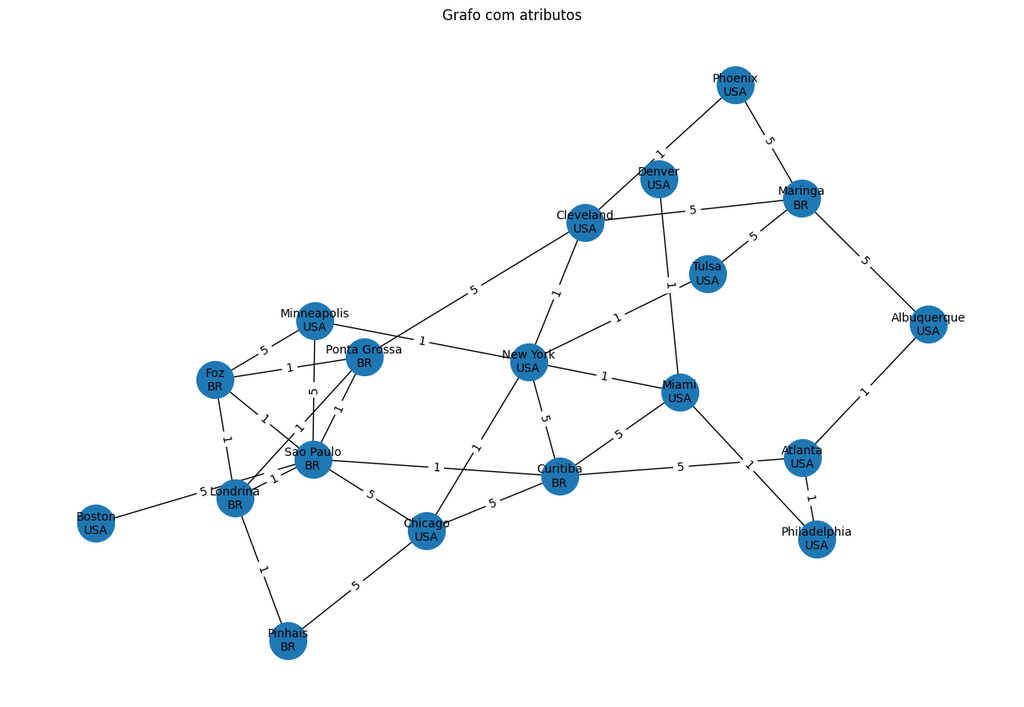

```python
# Draw the graph with labels and attributes
plt.figure(figsize=(12, 8))

# Draw nodes with labels and attributes
pos = nx.spring_layout(G)  # Positioning nodes
nx.draw(G, pos, with_labels=False, node_size=1000)

# Draw node attributes (Country) side by side with node labels
node_attributes = nx.get_node_attributes(G, 'Country')
for node, (x, y) in pos.items():
    plt.text(x, y, f"{node}\n{node_attributes[node]}", fontsize=10, ha='center', va='center')

# Draw edge attributes
edge_labels = nx.get_edge_attributes(G, 'Cost')
nx.draw_networkx_edge_labels(G, pos, edge_labels=edge_labels)

plt.title("Grafo com atributos")
plt.axis('off')  # Turn off axis
plt.show()
```